# Sample Survey

Nzambuli Daniel

2023-11-27

# One

Foresters want to estimate the average age of trees in a stand. Determining age is cumbersome, because one needs to count the tree rings on a core taken from the tree. In general, though, the older the tree the larger the diameter, and diameter is easy to measure. The foresters measure the diameter of all 1132 trees and find that the population mean equals 10.3. they then randomly select 20 trees for age measurement

[output not shown]

```r
data_q1 = data.frame(tree_no = seq(1,20),
                     diameter_x = c(12, 11.4, 7.9, 10.5, 7.9, 9, 7.3, 10.2,11.7, 11.3, 5.7, 8, 10.3, 12, 9.2, 8.5,7.0, 10.7, 9.3, 8.2),
                     age_y = c(125, 119, 83, 85, 99, 117, 69, 133, 154, 168, 61, 80, 114, 147, 122, 106, 82, 88, 97, 99))
View(data_q1)
```

## a. Draw a scatter plot of y vs x

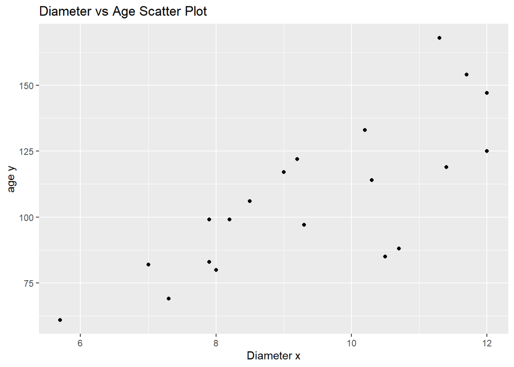

```r
library(ggplot2)
ggplot(data_q1, aes(x = diameter_x, y = age_y))+
  geom_point()+
  labs(x = "Diameter x",
       y = "age y",
       title = "Diameter vs Age Scatter Plot")
```

$$y_i = age = variable\ hard\ to\ predict\\\ \\
t_y = \sum^n_{i = 1} y_i\\\ \\
x_i = diameter = known\ variable\\\ \\
t_x = \sum^n_{i = 1} x_i\\\ \\$$

using ratio estimates

$$\frac{t_y}{t_x} = \frac{\mu_y}{\mu_x}\\\ \\
\mu_x = population\ diameter\ mean = 10.3\\\ \\
\mu_y = population\ mean\ age = \mu_x * \frac{t_y}{t_x}$$

$$= 10.3 * \frac{2148}{188.1} =\\\ \\\underline{117.6204147}$$

## c. Repeat (b) using regression estimation

$$m = \frac{n \sum{x* y} - \sum{x} * \sum {y}}{n * \sum{x^2} -
(\sum{x})^2}$$

| Tree no | Diameter x | age y | $x^2$ | x*y |
| --- | --- | --- | --- | --- |
| 1 | 12 | 125 | 144 | 1500 |
| 2 | 11.4 | 119 | 129.96 | 1356.6 |
| 3 | 7.9 | 83 | 62.41 | 655.7 |
| 4 | 10.5 | 85 | 110.25 | 892.5 |
| 5 | 7.9 | 99 | 62.41 | 782.1 |
| 6 | 9 | 117 | 81 | 1053 |
| 7 | 7.3 | 69 | 53.29 | 503.7 |
| 8 | 10.2 | 133 | 104.04 | 1356.6 |
| 9 | 11.7 | 154 | 136.89 | 1801.8 |
| 10 | 11.3 | 168 | 127.69 | 1898.4 |
| 11 | 5.7 | 61 | 32.49 | 347.7 |
| 12 | 8 | 80 | 64 | 640 |
| 13 | 10.3 | 114 | 106.09 | 1174.2 |
| 14 | 12 | 147 | 144 | 1764 |
| 15 | 9.2 | 122 | 84.64 | 1122.4 |
| 16 | 8.5 | 106 | 72.25 | 901 |
| 17 | 7 | 82 | 49 | 574 |
| 18 | 10.7 | 88 | 114.49 | 941.6 |
| 19 | 9.3 | 97 | 86.49 | 902.1 |
| 20 | 8.2 | 99 | 67.24 | 811.8 |
| **Total** | **188.1** | **2148** | **1832.63** | **20979.2** |

$$m = \frac{(20 * 20979.2) - (188.1 * 2148)}{(20*1832.63) - 188.1^2}\\\ \\
=12. 23078073\\\ \\
c = \frac{\sum{y} - m\sum{x}}{n}\\\ \\
= \frac{2148 - 12.23078073(188.1)}{20}\\\ \\
= -7.6303492765$$

equation can be written as

$$y = b_0 + b_1x : \\\ \\
age = -7.63 + 12.23\ diameter\\\ \\
age = (12.23078073*10.3)- 7.6303492765 = 118.3467$$

average age is $\underline{118.3467}$

## d. Label your estimates on your graph. How do they compare?

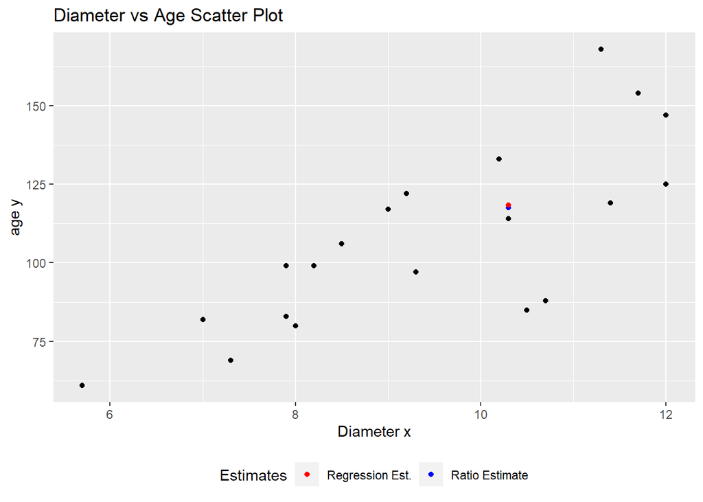

```r
scatter_plot = ggplot(data_q1, aes(x = diameter_x, y = age_y))+
  geom_point()+
  labs(x = "Diameter x",
       y = "age y",
       title = "Diameter vs Age Scatter Plot")
estimates = c(117.6204147, 118.3467)
colour = c("red", "blue")
type = c("Regression Est.","Ratio Estimate")
point_est = data.frame(estimates, colour, type)
scatter_plot+geom_point(data = point_est, aes(x =10.3, y = estimates, color = colour), shape = 19)+
  scale_color_manual(values = colour,
                     labels = type,
                     name = "Y Points")+
  guides(color = guide_legend(title = "Estimates"))+
  theme(legend.position = "bottom")
```

the regression estimate, ratio estimate and the population value fall around a similar position when the population mean of diameter is 10.3. This means that the error may be negligible.

# Two

The new candy Green Globules is being test-marketed in an area of upstate New York. The market research decided to sample 6 cities from the 45 cities in the area and then to sample supermarkets within cities, wanting to know the number of cases of Green Globules sold

| City | No of supermarkets | Number of cases sold |
| --- | --- | --- |
| 1 | 52 | 146, 180, 251, 152, 72, 181, 171, 361, 73, 186 |
| 2 | 19 | 99, 101, 52, 121 |
| 3 | 37 | 199, 179, 98, 63, 126, 87, 62 |
| 4 | 39 | 226, 129, 57, 46, 86, 43, 85, 165 |
| 5 | 8 | 12, 23 |
| 6 | 14 | 87, 43, 59 |

## a. Obtain summary statistics for each cluster

$$cluster\ mean = \bar{x} = \frac{\sum^{n}_{i = 1}x_i}{n}\\\ \\
cluster\ standard\ deviation = \sqrt{\frac{\sum{(x_i - \bar{x})^2}}{n
-1}}$$

1. **City 1**

$$\bar{x} = \frac{146+180+251+ 152+72+181+171+361+73+186}{10} = 177.3$$

| x | $(x - \bar{x})$ | $(x - \bar{x})^2$ |
| --- | --- | --- |
| 146 | -31.3 | 979.69 |
| 180 | 2.7 | 7.29 |
| 251 | 73.7 | 5431.69 |
| 152 | -25.3 | 640.09 |
| 72 | -105.3 | 11088.09 |
| 181 | 3.7 | 13.69 |
| 171 | -6.3 | 39.69 |
| 361 | 183.7 | 33745.69 |
| 73 | -104.3 | 10878.49 |
| 186 | 8.7 | 75.69 |
| **Totals** |  | **62900.1** |

standard deviation

$$sx =\sqrt{
\frac{979.69+7.29+5431.69+640.09+11088.09+13.69+39.69+33745.69+10878.49+75.69}{10
-1}}\\\ \\
= \sqrt{\frac{62900.1}{9}} = 83.59964$$

minumum `72`

maximum `361`

### Summary

[output not shown]

## b. Estimate the total number of cases sold, and the average number sold per supermarket, along with the standard errors of your estimates

$$\mu = \frac{1}{N}*\sum^{N}_{i = 1} N_i * \bar{x_i}\\\ \\
= \frac{1}{169}[(52 * 177.3) + (19 *93.25) + (37 * 116.27) + (39
*104.625) + (8 * 17.5) + (14 * 63)]\\\ \\
\underline{120.6847}$$

total cases sold

$$\mu * N = 120.6847 * 169\\\ \\
20395.71\\\ \\
cases\ sold\ = 20396$$

average case per supermarket

$$121\ cases\ per\ supermarket$$

mean sampling error

$$var(\mu) = \sum^N_{h= 1} (\frac{N_h}{N})^2 * (\frac{N_h -
n_h}{N_h})*\frac{s_h^2}{n_h}\\\ \\
(\frac{52}{169})^2 * \frac{52 - 10}{52} * \frac{83.59964^2}{10} +\\\ \\
(\frac{19}{169})^2 * \frac{19 - 4}{19} * \frac{29.23895803^2}{4}+\\\ \\
(\frac{37}{169})^2 * \frac{37 - 7}{7} * \frac{54.53963172^2}{7}+\\\ \\
(\frac{39}{169})^2 * \frac{39 - 8}{39} * \frac{54.5930945^2}{8}+\\\ \\
(\frac{8}{169})^2 * \frac{8 - 2}{8} * \frac{7.778174593^2}{2}+\\\ \\
(\frac{14}{169})^2 * \frac{14 - 3}{14} * \frac{22.27105745^2}{3}$$

The MSE is $\underline{88.8028345}$